Download this document as a JupyterLab notebook [here](http://54.243.252.9/ce-3354-webroot/2-Exercises/ES-7/es7.ipynb)

# CE 3354 Engineering Hydrology Fall 2022 Exercise Set 7

**LAST NAME, FIRST NAME**

**R00000000**

### Purpose :

Prepare design storms for Hardin Creek Project analysis.

### Assessment Criteria :

Completion, plausible solutions, use of Jupyter Notebook as a calculator/documentation method

## Exercise 1:

Use NOAA Atlas 14 (Precipitation Frequency Data Server) to prepare Depth-Duration-Frequency curves for Eden, Texas (Concho County). The desired durations are 30-min, 1-hour, 2-hour, 3-hour, 6-hour, 12-hour, and 24-hour. The desired ARI are 2-yr, 10-yr, 50-yr, and 100-yr. You will produce a total of 4 curves.

Solution:

Either get the images directly as below:

[figure not shown]

Or download the tabular data and make own charts (which is the actual exercise because we need the values later on in the project)

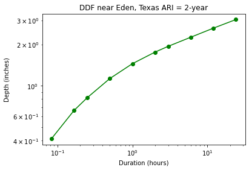

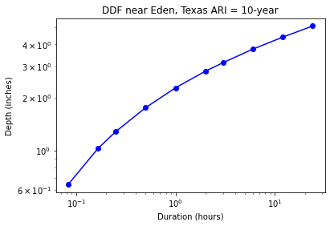

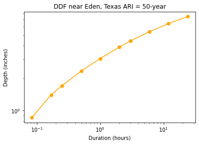

[figure not shown]

```python
# 2-yr

duration = [5/60,
10/60,
15/60,
30/60,
60/60,
2,
3,
6,
12,
24
]
depth = [0.412,
0.662,
0.82,
1.13,
1.45,
1.76,
1.94,
2.26,
2.63,
3.04
]
ari = "2-year"
from matplotlib import pyplot as plt # import the plotting library from matplotlibplt.show()
plt.plot( duration, depth, color ='green', marker ='o', linestyle ='solid') # create a line chart, years on x-axis, gdp on y-axi
plt.xscale('log')
plt.yscale('log')
plt.title("DDF near Eden, Texas ARI = " + ari)# add a title
plt.xlabel("Duration (hours)")# add a label to the x and y-axes
plt.ylabel("Depth (inches)")
plt.show() # display the plot

# 10-yr

duration = [5/60,
10/60,
15/60,
30/60,
60/60,
2,
3,
6,
12,
24
]
depth = [0.643,
1.03,
1.28,
1.75,
2.27,
2.82,
3.15,
3.76,
4.4,
5.09
]
ari = "10-year"
from matplotlib import pyplot as plt # import the plotting library from matplotlibplt.show()
plt.plot( duration, depth, color ='blue', marker ='o', linestyle ='solid') # create a line chart, years on x-axis, gdp on y-axi
plt.xscale('log')
plt.yscale('log')
plt.title("DDF near Eden, Texas ARI = " + ari)# add a title
plt.xlabel("Duration (hours)")# add a label to the x and y-axes
plt.ylabel("Depth (inches)")
plt.show() # display the plot

# 50-yr

duration = [5/60,
10/60,
15/60,
30/60,
60/60,
2,
3,
6,
12,
24
]
depth = [0.86,
1.39,
1.7,
2.32,
3.03,
3.87,
4.41,
5.38,
6.39,
7.43,
]
ari = "50-year"
from matplotlib import pyplot as plt # import the plotting library from matplotlibplt.show()
plt.plot( duration, depth, color ='orange', marker ='o', linestyle ='solid') # create a line chart, years on x-axis, gdp on y-axi
plt.xscale('log')
plt.yscale('log')
plt.title("DDF near Eden, Texas ARI = " + ari)# add a title
plt.xlabel("Duration (hours)")# add a label to the x and y-axes
plt.ylabel("Depth (inches)")
plt.show() # display the plot

# 100-yr

duration = [5/60,
10/60,
15/60,
30/60,
60/60,
2,
3,
6,
12,
24
]
depth = [0.949,
1.53,
1.88,
2.55,
3.35,
4.33,
4.99,
6.15,
7.35,
8.58,
]
ari = "100-year"
from matplotlib import pyplot as plt # import the plotting library from matplotlibplt.show()
plt.plot( duration, depth, color ='red', marker ='o', linestyle ='solid') # create a line chart, years on x-axis, gdp on y-axi
plt.xscale('log')
plt.yscale('log')
plt.title("DDF near Eden, Texas ARI = " + ari)# add a title
plt.ylabel("Duration (hours)")# add a label to the x and y-axes
plt.xlabel("Depth (inches)")
plt.show() # display the plot
```

## Exercise 2:

Use the results in Exercise 1 (above) to prepare Intensity-Duration-Frequency curves for Eden, Texas (Concho County). The desired durations are 30-min, 1-hour, 2-hour, 3-hour, 6-hour, 12-hour, and 24-hour. The desired ARI are 2-yr, 10-yr, 50-yr, and 100-yr. You will produce a total of 4 curves.

Solution:

Use the scripts above, divide by the duration to get intensity

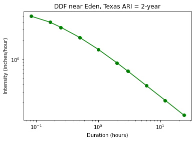

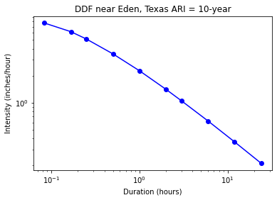

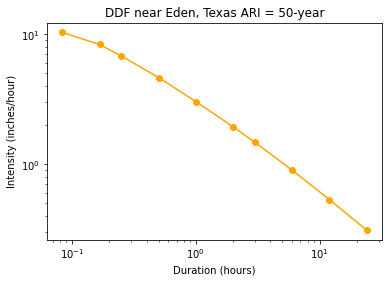

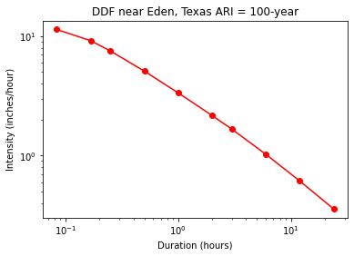

```python
# 2-yr

duration = [5/60,
10/60,
15/60,
30/60,
60/60,
2,
3,
6,
12,
24
]
depth = [0.412,
0.662,
0.82,
1.13,
1.45,
1.76,
1.94,
2.26,
2.63,
3.04
]
intensity = []
for i in range(len(depth)):
    intensity.append(depth[i]/duration[i])
ari = "2-year"
from matplotlib import pyplot as plt # import the plotting library from matplotlibplt.show()
plt.plot( duration, intensity, color ='green', marker ='o', linestyle ='solid') # create a line chart, years on x-axis, gdp on y-axi
plt.yscale('log')
plt.xscale('log')
plt.title("DDF near Eden, Texas ARI = " + ari)# add a title
plt.xlabel("Duration (hours)")# add a label to the x and y-axes
plt.ylabel("Intensity (inches/hour)")
plt.show() # display the plot

# 10-yr

duration = [5/60,
10/60,
15/60,
30/60,
60/60,
2,
3,
6,
12,
24
]
depth = [0.643,
1.03,
1.28,
1.75,
2.27,
2.82,
3.15,
3.76,
4.4,
5.09
]
intensity = []
for i in range(len(depth)):
    intensity.append(depth[i]/duration[i])
ari = "10-year"
from matplotlib import pyplot as plt # import the plotting library from matplotlibplt.show()
plt.plot( duration, intensity, color ='blue', marker ='o', linestyle ='solid') # create a line chart, years on x-axis, gdp on y-axi
plt.yscale('log')
plt.xscale('log')
plt.title("DDF near Eden, Texas ARI = " + ari)# add a title
plt.xlabel("Duration (hours)")# add a label to the x and y-axes
plt.ylabel("Intensity (inches/hour)")
plt.show() # display the plot

# 50-yr

duration = [5/60,
10/60,
15/60,
30/60,
60/60,
2,
3,
6,
12,
24
]
depth = [0.86,
1.39,
1.7,
2.32,
3.03,
3.87,
4.41,
5.38,
6.39,
7.43,
]
intensity = []
for i in range(len(depth)):
    intensity.append(depth[i]/duration[i])
ari = "50-year"
from matplotlib import pyplot as plt # import the plotting library from matplotlibplt.show()
plt.plot( duration, intensity, color ='orange', marker ='o', linestyle ='solid') # create a line chart, years on x-axis, gdp on y-axi
plt.yscale('log')
plt.xscale('log')
plt.title("DDF near Eden, Texas ARI = " + ari)# add a title
plt.xlabel("Duration (hours)")# add a label to the x and y-axes
plt.ylabel("Intensity (inches/hour)")
plt.show() # display the plot

# 100-yr

duration = [5/60,
10/60,
15/60,
30/60,
60/60,
2,
3,
6,
12,
24
]
depth = [0.949,
1.53,
1.88,
2.55,
3.35,
4.33,
4.99,
6.15,
7.35,
8.58,
]
intensity = []
for i in range(len(depth)):
    intensity.append(depth[i]/duration[i])
ari = "100-year"
from matplotlib import pyplot as plt # import the plotting library from matplotlibplt.show()
plt.plot( duration, intensity, color ='red', marker ='o', linestyle ='solid') # create a line chart, years on x-axis, gdp on y-axi
plt.yscale('log')
plt.xscale('log')
plt.title("DDF near Eden, Texas ARI = " + ari)# add a title
plt.xlabel("Duration (hours)")# add a label to the x and y-axes
plt.ylabel("Intensity (inches/hour)")
plt.show() # display the plot
```

**Note** graphs would look nicer on a single plot, but not what problem asked for

## Exercise 3:

Use NOAA Atlas 14 and the SCS Rainfall Distributions to prepare a 50-yr, 24- hour balanced-storm hyetograph for Eden, Texas. Use the correct Type storm for Eden Texas. Make a plot of the design storm with time on the horizontal axis (left-right) and cumulative depth on the vertical (up-down).

Solution:

Use script from lecture , adjust to correct depth for Eden, Texas

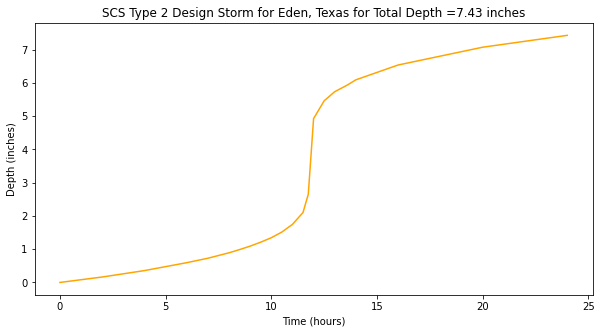

```python
# SCS design storm

hour = [0,2,4,6,7,8,8.5,9,9.5,9.75,10,10.5,11,11.5,11.75,12,12.5,13.0,13.6,14,16,20,24]
type2 = [0,0.022,0.048,0.08,0.098,0.12,0.133,0.147,0.163,0.172,0.181,0.204,0.235,0.283,0.357,0.663,0.735,0.772,0.799,0.82,0.88,0.952,1]

Ptotal = 7.43
T2D =[0 for i in range(len(hour))]
for i in range(len(hour)):
    T2D[i]=Ptotal*type2[i]
#plot

import matplotlib.pyplot as plt # the python plotting library
plottitle ='SCS Type 2 Design Storm for Eden, Texas for Total Depth =' + str(Ptotal) +' inches'
mydata = plt.figure(figsize = (10,5)) # build a square drawing canvass from figure class
plt.plot(hour, T2D, c='orange') # step plot
#plt.plot(time, accumulate, c='blue',drawstyle='steps') # step plot
plt.xlabel('Time (hours)')
plt.ylabel('Depth (inches)')
plt.title(plottitle)
plt.show()
```

## Exercise 4:

Use the Texas Hyetograph Tool [TxHYETO-2015.xlsx](http://54.243.252.9/toolbox/hydrology/EBDLKUP-2015-DISTRIBUTE/) and NOAA Atlas 14 to prepare a 50-yr, 24-hour hyetograph for Eden, Texas. Make a plot of the design storm with time on the horizontal axis (left-right) and cumulative depth on the vertical (up-down).

Solution:

Use TxHYETO to interpolate from 50-yr depth, then plot

[figure not shown]

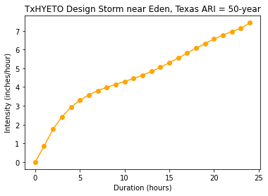

```python
time = [0.00,
1.00,
2.00,
3.00,
4.00,
5.00,
6.00,
7.00,
8.00,
9.00,
10.00,
11.00,
12.00,
13.00,
14.00,
15.00,
16.00,
17.00,
18.00,
19.00,
20.00,
21.00,
22.00,
23.00,
24.00
]
depth = [0.000,
0.848,
1.750,
2.417,
2.919,
3.298,
3.586,
3.808,
3.988,
4.146,
4.298,
4.458,
4.635,
4.833,
5.054,
5.295,
5.549,
5.810,
6.070,
6.321,
6.556,
6.770,
6.959,
7.123,
7.430
]

ari = "50-year"
from matplotlib import pyplot as plt # import the plotting library from matplotlibplt.show()
plt.plot( time, depth, color ='orange', marker ='o', linestyle ='solid') # create a line chart, years on x-axis, gdp on y-axi
#plt.yscale('log')
#plt.xscale('log')
plt.title("TxHYETO Design Storm near Eden, Texas ARI = " + ari)# add a title
plt.xlabel("Duration (hours)")# add a label to the x and y-axes
plt.ylabel("Intensity (inches/hour)")
plt.show() # display the plot
```

**Note 1** You will use these hyetographs in the Hardin Creek Project, so save your work.